# Reproducible Research - Peer Accessment 1

Feiyin Wu

July 19, 2015

```r
knitr:: opts_chunk$set(echo = TRUE)
```

## Loading and preprocessing the data

```r
activity <- read.csv("activity.csv")
```

## What is mean total number of steps taken per day?

1. Calculate the total number of steps taken per day

```r
total_steps_per_day <- tapply(activity$steps, activity$date, sum, na.rm = T)
print(total_steps_per_day)
```

```
## 2012-10-01 2012-10-02 2012-10-03 2012-10-04 2012-10-05 2012-10-06
##          0        126      11352      12116      13294      15420
## 2012-10-07 2012-10-08 2012-10-09 2012-10-10 2012-10-11 2012-10-12
##      11015          0      12811       9900      10304      17382
## 2012-10-13 2012-10-14 2012-10-15 2012-10-16 2012-10-17 2012-10-18
##      12426      15098      10139      15084      13452      10056
## 2012-10-19 2012-10-20 2012-10-21 2012-10-22 2012-10-23 2012-10-24
##      11829      10395       8821      13460       8918       8355
## 2012-10-25 2012-10-26 2012-10-27 2012-10-28 2012-10-29 2012-10-30
##       2492       6778      10119      11458       5018       9819
## 2012-10-31 2012-11-01 2012-11-02 2012-11-03 2012-11-04 2012-11-05
##      15414          0      10600      10571          0      10439
## 2012-11-06 2012-11-07 2012-11-08 2012-11-09 2012-11-10 2012-11-11
##       8334      12883       3219          0          0      12608
## 2012-11-12 2012-11-13 2012-11-14 2012-11-15 2012-11-16 2012-11-17
##      10765       7336          0         41       5441      14339
## 2012-11-18 2012-11-19 2012-11-20 2012-11-21 2012-11-22 2012-11-23
##      15110       8841       4472      12787      20427      21194
## 2012-11-24 2012-11-25 2012-11-26 2012-11-27 2012-11-28 2012-11-29
##      14478      11834      11162      13646      10183       7047
## 2012-11-30
##          0
```

2. Histogram of the total number of steps taken per day

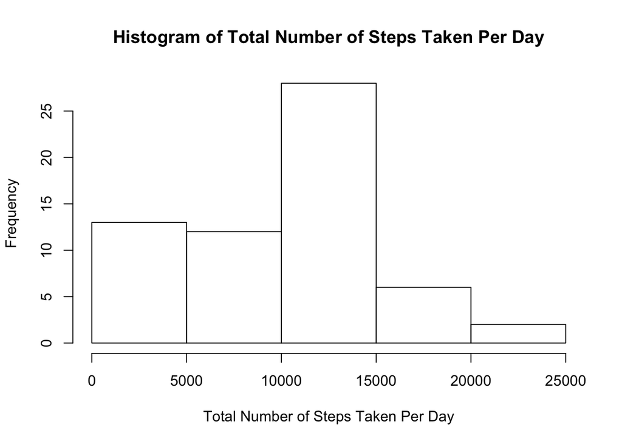

```r
hist(total_steps_per_day, xlab = "Total Number of Steps Taken Per Day", main = "Histogram of Total Number of Steps Taken Per Day")
```

3. Mean & Median of the total number of steps taken per day

```r
mean <- round(mean(total_steps_per_day),2)
median <- median(total_steps_per_day)

paste("The mean of the total number of steps taken per day is", mean)
```

```
## [1] "The mean of the total number of steps taken per day is 9354.23"
```

```r
paste("The median of the total number of steps taken per day is", median)
```

```
## [1] "The median of the total number of steps taken per day is 10395"
```

## What is the average daily activity pattern?

1. Time series plot of the 5-minute interval and the average number of steps taken

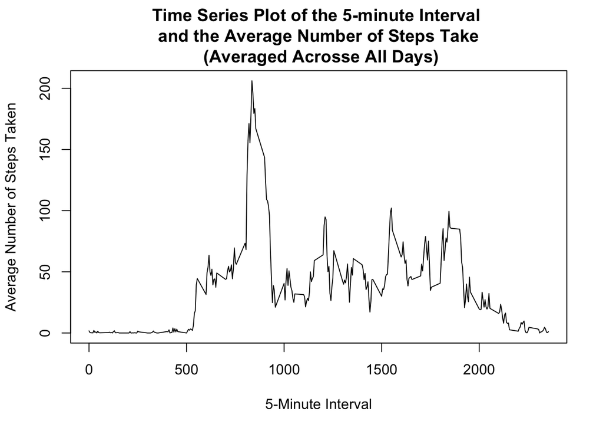

```r
average_steps_per_interval <- tapply(activity$steps, activity$interval, mean, na.rm = T)
plot(average_steps_per_interval ~ unique(activity$interval), type = "l", xlab = "5-Minute Interval", ylab = "Average Number of Steps Taken", main = "Time Series Plot of the 5-minute Interval \n and the Average Number of Steps Take \n (Averaged Acrosse All Days)")
```

2. The 5-minute interval that contains the maximum number of steps across all the days

```r
max_interval <- names(average_steps_per_interval[which.max(average_steps_per_interval)])
paste(max_interval,"is the 5-minute interval that contains the maximum number of steps. The steps value is", max(average_steps_per_interval))
```

```
## [1] "835 is the 5-minute interval that contains the maximum number of steps. The steps value is 206.169811320755"
```

## Imputing missing values

1. Total number of missing value in the dataset.

```r
total_missing_value <- nrow(activity[!complete.cases(activity),])

paste("The total number of missing values in the dataset is", total_missing_value)
```

```
## [1] "The total number of missing values in the dataset is 2304"
```

2. Strategy for filling in all of the missing values in the dataset I’m going to use the mean for that 5-minute interval to fill in all of the missing values in the dataset.
3. Create a new dataset with the missing data filled in.

```r
activity_complete <- activity
for (i in 1:nrow(activity)){
    if (is.na(activity$steps[i])){
        activity_complete$steps[i] <- average_steps_per_interval[[as.character(activity[i,"interval"])]]
    }
}
```

4. Analysis of the new activity_complete dataset
1. Histogram of the total number of steps taken each day with complete dataset

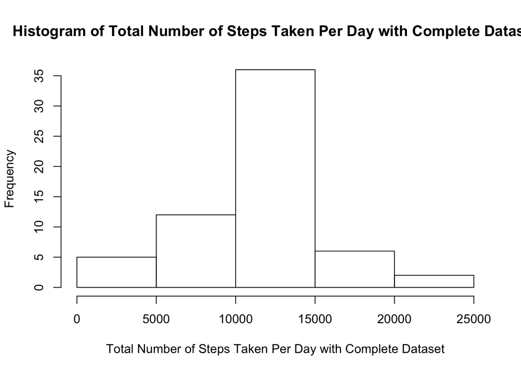

```r
total_steps_per_day_complete <- tapply(activity_complete$steps, activity_complete$date, sum, na.rm = T)
hist(total_steps_per_day_complete, xlab = "Total Number of Steps Taken Per Day with Complete Dataset", main = "Histogram of Total Number of Steps Taken Per Day with Complete Dataset")
```

2. Mean & Median of the total number of steps taken per day with complete dataset

```r
mean_complete <- round(mean(total_steps_per_day_complete),2)
median_complete <- median(total_steps_per_day_complete)

paste("The mean of the total number of steps taken per day with complete dataset is", mean)
```

[output not shown]

```r
paste("The median of the total number of steps taken per day with complete dataset is", median)
```

[output not shown]

## Are there differences in activity patterns between weekdays and weekends?

1. Create new factor variable to indicate “weekday” and “weekend”

```r
activity_complete$DayOfWeek <- 0
for (i in 1:nrow(activity_complete)){
    if (weekdays(as.Date(activity_complete$date[i])) %in% c("Saturday","Sunday")) {
        activity_complete$DayOfWeek[i] <- "Weekend"
    } else {
        activity_complete$DayOfWeek[i] <- "Weekday"
    }
}
```

2. Panel plot with a time series plot of the 5-minute interval and the average number of steps taken, averaged across all weekday days or weekend days

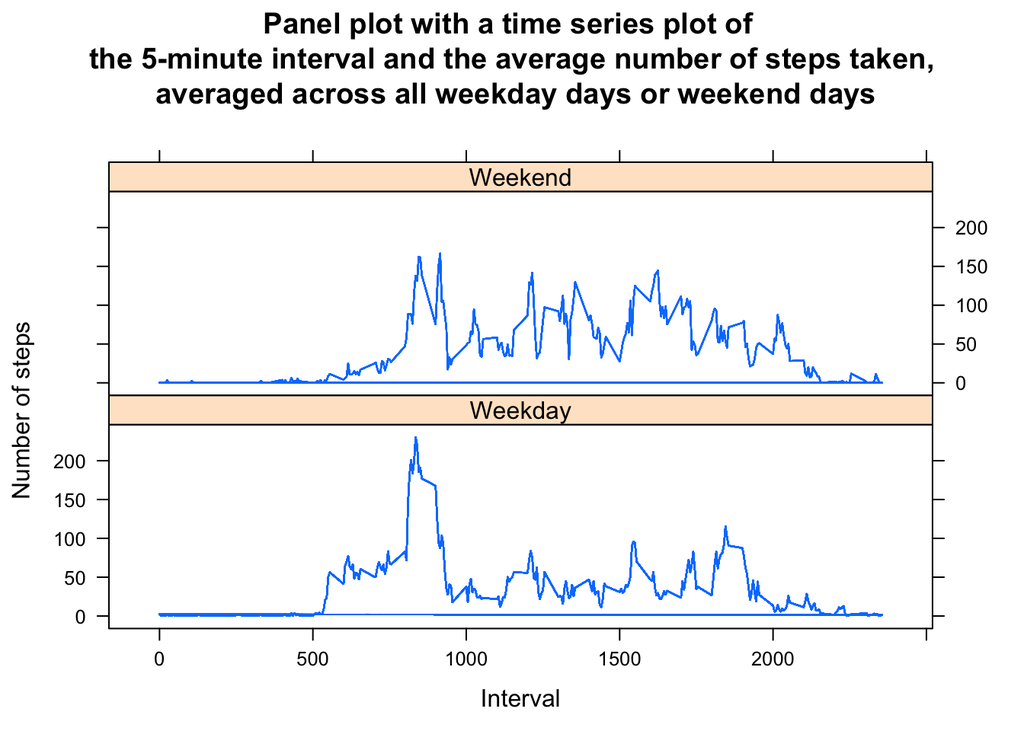

```r
library(lattice)

activity_complete_weekday <- subset(activity_complete, activity_complete$DayOfWeek == "Weekday")
activity_complete_weekend <- subset(activity_complete, activity_complete$DayOfWeek == "Weekend")

average_steps_per_interval_weekday <- tapply(activity_complete_weekday$steps, activity_complete_weekday$interval, mean, na.rm = T)
average_steps_per_interval_weekend <- tapply(activity_complete_weekend$steps, activity_complete_weekend$interval, mean, na.rm = T)

weekday <- data.frame(interval = unique(activity_complete_weekday), Average = as.numeric(average_steps_per_interval_weekday))
weekend <- data.frame(interval = unique(activity_complete_weekend), Average = as.numeric(average_steps_per_interval_weekend))
activity_complete2 <- rbind(weekday,weekend)

xyplot(Average ~ interval.interval | interval.DayOfWeek, data = activity_complete2, layout = c(1, 2), type = "l", xlab = "Interval", ylab = "Number of steps", main = "Panel plot with a time series plot of \n the 5-minute interval and the average number of steps taken, \n averaged across all weekday days or weekend days")
```